# Conflito e negociação

Comportamento Organizacional

Luis F. Gómez L.

luis.gomezl@unimilitar.edu.co

Faculdade de Educação a Distância

27 outubro, 2025

# O que fazem os administradores?

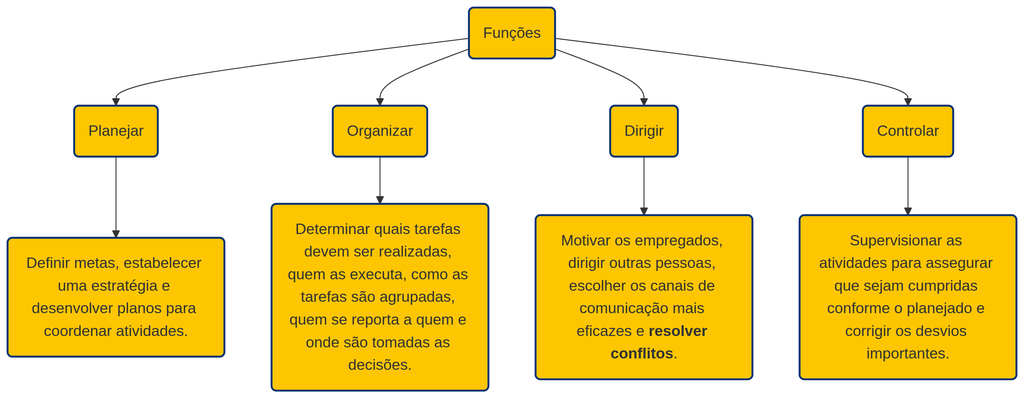

Figura 1: Funções dos administradores (Robbins & Judge, 2024, p. 40)

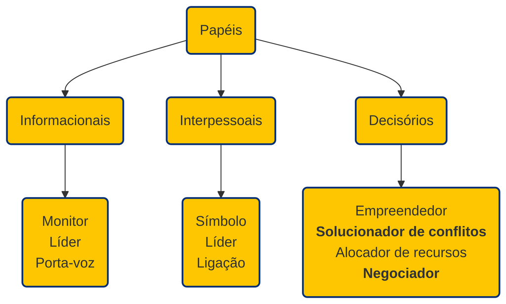

Figura 2: Papéis dos administradores segundo Mintzberg (Robbins & Judge, 2024, pp. 41–42)

# Modelo Básico do Comportamento Organizacional

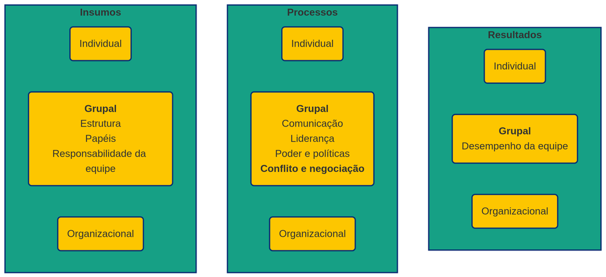

Figura 3: Modelo Básico do Comportamento Organizacional (Robbins & Judge, 2024, p. 61)

# Conflito

**Definição 1 (Conflito)** O conflito é uma manifestação entre pelo menos duas partes interdependentes que percebem objetivos incompatíveis e a interferência de outros no alcance de seus objetivos. (Hocker & Wilmot, 2018, p. 3)

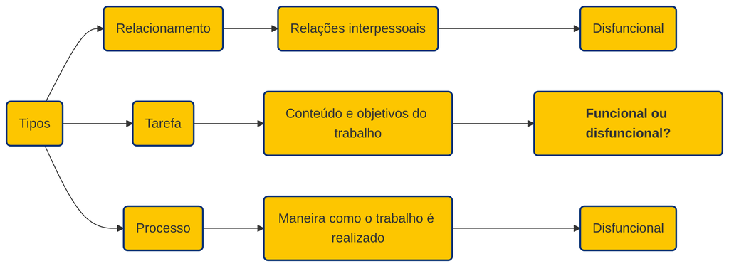

Figura 4: Tipos de conflitos (Robbins & Judge, 2024, pp. 479–481)

O processo do conflito refere-se à sequência de eventos que ocorre durante um conflito e à maneira pela qual os eventos anteriores influenciam os eventos posteriores e os resultados (Thomas, 1992, p. 656).

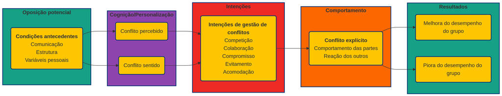

Figura 5: O processo do conflito (Robbins & Judge, 2024, pp. 482–489)

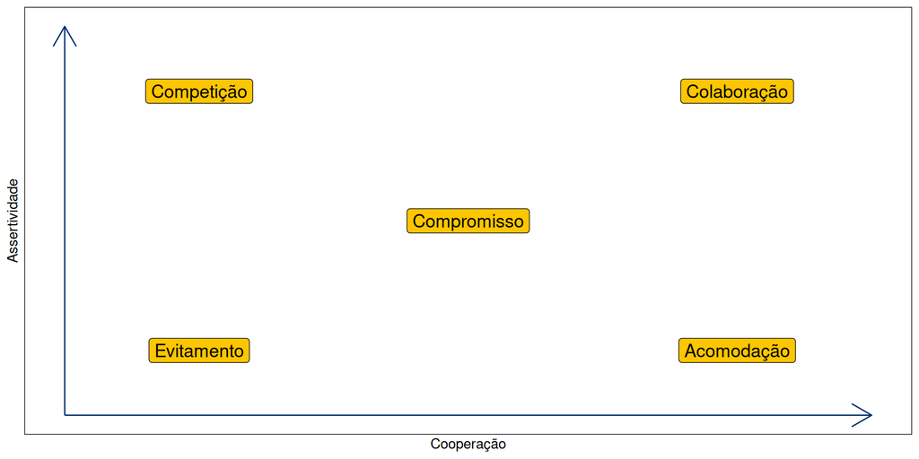

Figura 6: Intenções de gestão do conflito (Robbins & Judge, 2024, p. 486)

# Negociação

**Definição 2 (Negociação)** A negociação é um processo de tomada de decisão em que duas ou mais partes conversam entre si em um esforço para resolver seus interesses opostos (Lewicki et al., 2024, p. 3).

Tabela 1: Estratégias de negociação (Robbins & Judge, 2024, p. 491)

| Características | Distributiva | Integrativa |
| --- | --- | --- |
| Objetivo | Reivindicar valor | Criar valor |
| Motivação | Ganha–Perde | Ganha–Ganha |
| Enfoque | Posturas | Interesses |
| Compartilhar informações | Baixa | Alta |
| Relação | De curto prazo | De longo prazo |

Tabela 2: Integração de estratégias distributivas e integrativas (Robbins & Judge, 2024, p. 460)

| Etapa | Tipo de estratégia | Ação central | Objetivo |
| --- | --- | --- | --- |
| Esclarecer necessidades | Integrativa | Compreender as necessidades de ambas as partes | Construir confiança e base de informação |
| Articular interesses | Integrativa | Tornar claros os interesses | Identificar potencial de ganhos mútuos |
| Evitar concessões precoces | Integrativa | Adiar concessões | Manter espaço para soluções criativas |
| Definir metas elevadas | Distributiva | Estabelecer metas ambiciosas | Capturar valor de forma prudente |
| Dividir o “bolo” | Distributiva | Gerir concessões de forma progressivamente menor | Finalizar a distribuição do valor |

A parte distributiva não contradiz a integrativa, ela a complementa. Você pode pensar da seguinte forma:

> *Colabore no início para expandir o bolo, depois compita de forma inteligente para dividi-lo.*

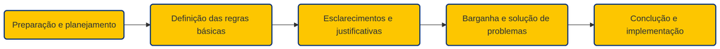

Figura 7: O processo de negociação (Robbins & Judge, 2024, pp. 495–497)

# Simulação

- **Instruções da simulação**[^1]
  - *Objetivo a negociar*
    - Cada estudante pode escolher entre duas opções para aumentar sua nota final:
      - Opção A: aumentar 0,5 pontos
      - Opção B: aumentar 1 ponto
    - *Condição*:
      - Se mais de 10% da turma escolher a Opção B, nenhum estudante receberá pontos adicionais.
      - Se 10% ou menos escolherem a Opção B, cada estudante receberá o aumento correspondente à opção escolhida.

      Portanto, os estudantes devem negociar coletivamente como proceder.
- *Etapa 1 – Negociação coletiva*
  - A turma terá um tempo limitado para conversar e se coordenar.
  - Podem discutir estratégias, acordos ou compromissos comuns.
- *Etapa 2 – Decisão individual e anônima*
  - Após a negociação, cada estudante escolherá de forma individual e secreta entre a Opção A ou a Opção B.
  - Todas as respostas serão recolhidas de maneira anônima, acessando o seguinte link

    [Clique aqui para acessar o formulário](https://forms.gle/y9to4hmik2VWbiVr5)
  - Uma vez recolhidas, o resultado final será calculado e comunicado a toda a turma.

Obrigado

# Referências

Hocker, J. L., & Wilmot, W. W. (2018). *Interpersonal conflict* (10.ª ed.). McGraw-Hill Education.

Lewicki, R. J., Saunders, D. M., & Barry, B. (2024). *Negotiation* (International student edition). McGraw Hill.

Robbins, S. P., & Judge, T. A. (2024). *Organizational behavior* (19th edition, global edition). Pearson. https://www-ebooks7-24-com.ezproxy.umng.edu.co/?il=28686

Selterman, D. (2019). Altruistic Punishment in the Classroom: An Update on the Tragedy of the Commons Extra Credit Question. *Teaching of Psychology*, *46*(2), 153–157. https://doi.org/10.1177/0098628319834208

Thomas, K. W. (1992). Conflict and negotiation processes in organizations. Em *Handbook of industrial and organizational psychology* (Vol. 3, pp. 651–717). Consulting Psychologists Press.

## Notas de rodapé

[^1]: Esta simulação é baseada em (Selterman, 2019)